## Loading and preprocessing the data

#### 1. Load the data

In order to start the project we first need to load the data from the course web site by clicking on the provided link, and downloading the repdata-data-activity.zip file into the R working directory. Once the zip file has been downloaded we then need to unzip the file to get the resulting file called activity.csv.

We will load activity.csv from the working directory and save it into a data.frame called activity in the following way:

```r
activity<-read.csv("activity.csv", header=TRUE)
```

#### 2. Process/transform the data (if necessary) into a format suitable for your analysis

The resulting dataframs has ~17k+ observations of three variables named steps, date, and interval. In order to perform any analysis on the resulting data from two things need to be done. 1. The “date” variable needs to be converted into a date format that R undertands 2. The “steps” variable has NA values in it that need to be mremoved We will prerform these two operations and assign the resulting data.frame to activity_clean

```r
library(lubridate)
activity_clean<-transform(activity, date=ymd(date))
activity_clean<-activity_clean[!is.na(activity_clean$steps),]
```

## What is mean total number of steps taken per day?

#### 1. Make a histogram of the total number of steps taken each day

The total number of steps taken per day can be plotted out by first calculating the steps taken per day using the following core

```r
steps_per_day<-data.frame(with(activity_clean, tapply(steps, date, sum)))
colnames(steps_per_day)<-"total.steps"
```

Next we can plot the histogram of the total steps taken per day

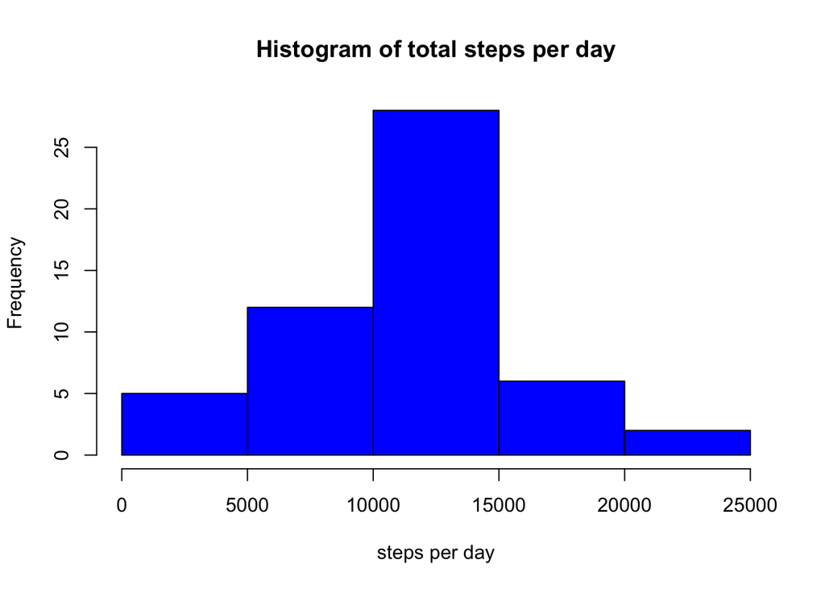

```r
hist(steps_per_day$total.steps, col="blue",
     main="Histogram of total steps per day",
     xlab="steps per day")
```

```r
mean_steps_perday<-mean(steps_per_day$total.steps)
median_steps_perday<-median(steps_per_day$total.steps)
```

## What is the average daily activity pattern?

#### 1. Make a time series plot (i.e. type = “l”) of the 5-minute interval (x-axis) and the average number of steps taken, averaged across all days (y-axis)

The average daily activity can be calculated by averaging steps accross the ‘interval’ variable. The following R code calculates the average and plots average daily activity in a time-series line graph.

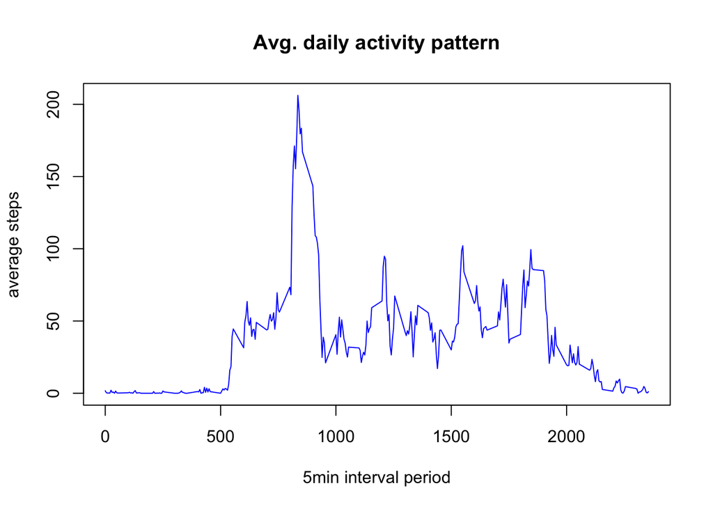

```r
average_daily_activity<-data.frame(with(activity_clean, tapply(steps, interval, mean)))
average_daily_activity<-transform(average_daily_activity,
                                  interval=as.numeric(rownames(average_daily_activity)))
colnames(average_daily_activity)<-c("avg.steps", "interval")
plot(average_daily_activity$interval, average_daily_activity$avg.steps, type='l',
     main="Avg. daily activity pattern",
     xlab="5min interval period",
     ylab="average steps",
     col="blue")
```

#### 2. Which 5-minute interval, on average across all the days in the dataset, contains the maximum number of steps?

Next we will look up the maximum daily, and check with 5 minute interval contains the max through subsetting the data.frame using the following R code:

```r
max_daily_activity<-max(average_daily_activity$avg.steps)
highest<-average_daily_activity[average_daily_activity$avg.steps==max_daily_activity, ]
highest<-highest$interval
```

835 is the interval that on average accross all the days in the dataset, contains the maximum number of steps.

## Imputing missing values

#### 1. Calculate and report the total number of missing values in the dataset (i.e. the total number of rows with NAs)

```r
library(lubridate)
activity_na<-activity[is.na(activity$steps),]
activity_na<-transform(activity_na, date=ymd(date))
number_of_nas<-dim(activity_na)[1]
```

There are 2304 NAs in the dataset

#### 2. Devise a strategy for filling in all of the missing values in the dataset.

Since there are a large amount of missing values in the dataset, it may influence our dataset. Therefore we will replace the NA values in the dataset with average values that existed during the five minute time period of the day

The following R code replaces the NAs with calculated values.

```r
int<-average_daily_activity$interval

for (i in int) {
    j<-as.numeric(average_daily_activity[average_daily_activity$interval==i, 1])
    activity_na[activity_na$interval==i,1]<-j
}
```

#### 3. Create a new dataset that is equal to the original dataset but with the missing data filled in

Now that we have replacement values for NA, we can merge the NA replacement dataset and the dataset with no NAs with the following r code

```r
activity_in<-rbind(activity_na, activity_clean)
```

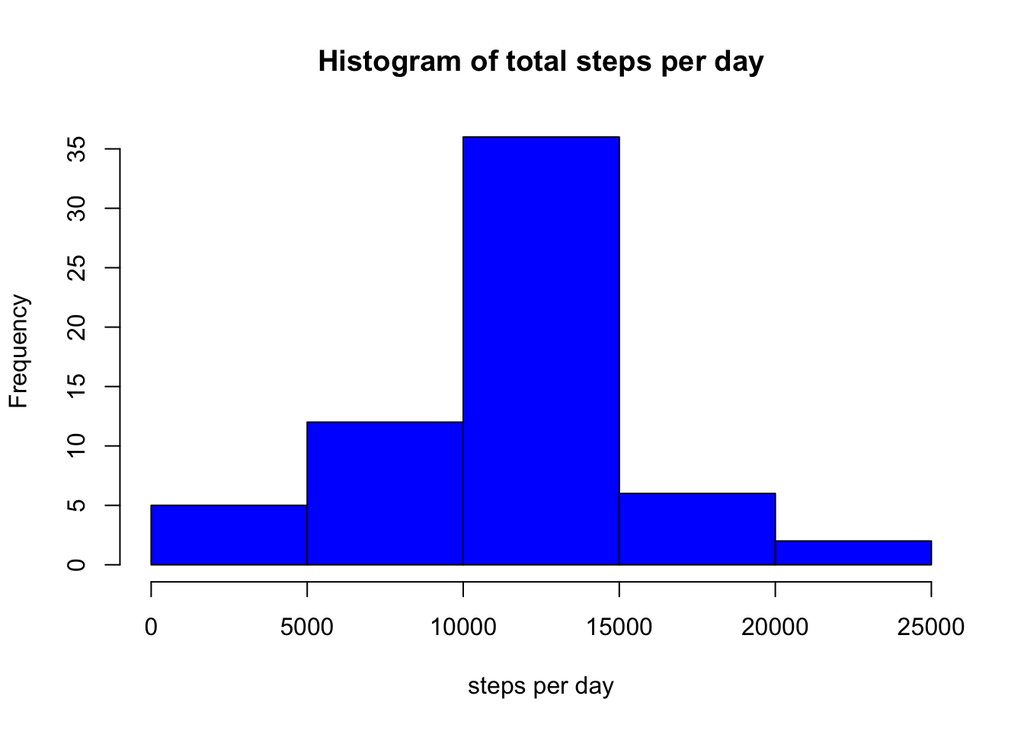

```r
steps_per_day_new<-data.frame(with(activity_in, tapply(steps, date, sum)))
colnames(steps_per_day_new)<-"total.steps"

hist(steps_per_day_new$total.steps, col="blue",
     main="Histogram of total steps per day",
     xlab="steps per day")
```

```r
mean_steps_new<-mean(steps_per_day_new$total.steps)
median_steps_new<-median(steps_per_day_new$total.steps)
```

## Are there differences in activity patterns between weekdays and weekends?

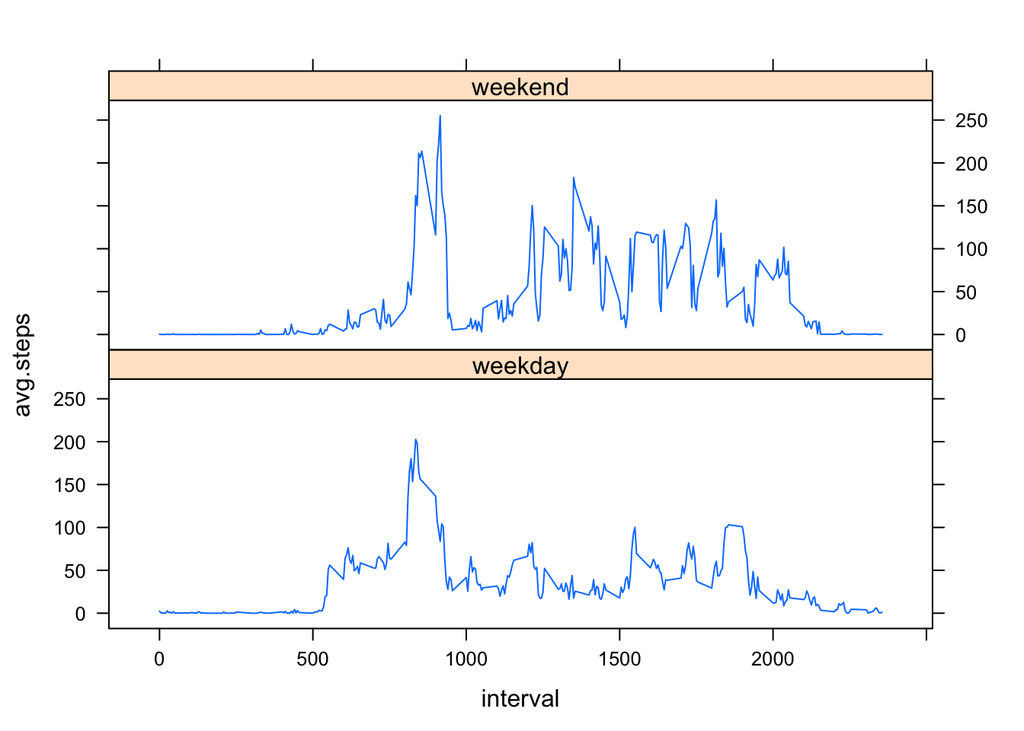

```r
library(lattice)
activity_in<-transform(activity_in, day=wday(date))
weekdays<-activity_in[activity_in$day<6,]
weekend<-activity_in[activity_in$day>6,]

average_week_activity<-data.frame(with(weekdays, tapply(steps, interval, mean)))
average_week_activity<-transform(average_week_activity,
                                  interval=as.numeric(rownames(average_week_activity)))
average_week_activity<-transform(average_week_activity,
                                  type="weekday")
colnames(average_week_activity)<-c("avg.steps", "interval", "type")
average_wend_activity<-data.frame(with(weekend, tapply(steps, interval, mean)))
average_wend_activity<-transform(average_wend_activity,
                                  interval=as.numeric(rownames(average_wend_activity)))
average_wend_activity<-transform(average_wend_activity,
                                  type="weekend")
colnames(average_wend_activity)<-c("avg.steps", "interval", "type")
combined_days<-rbind(average_week_activity, average_wend_activity)
combined_days<-transform(combined_days, type=as.factor(type))

xyplot(avg.steps~interval | type, data=combined_days, type="l", layout=c(1,2))
```